# CCN Synthesis Report

08 September 2026

## Introduction

The CCN clearinghouse provides a synthesized and curated set of coastal carbon data that promotes the sharing of open data, novel analyses, and collaboration opportunities. The synthesis is created by curating and merging publicly available data through an automated script. This report documents the success or failure of the automated synthesis process, documents changes, conducts QA/QC tests, and provides visualizations and summaries of data within the clearinghouse.

**Report date: 2026/09/08-11:59**

**Version: 1.8.0**

**Synthesis status: Successful**

**Contact: Jaxine Wolfe (wolfejax@si.edu)**

**Database Overview**

Currently, this synthesis contains 552 studies with soil carbon associated observations across 4161 sites and 16771 cores from around the world. Observations represent a 64 year timespan, from 1960 to 2024.

[interactive chart not shown]

## QA/QC

### Test Results Overview

|  | test | result |
| --- | --- | --- |
| 1 | Core ID uniqueness | Check the following core_id(s) in the core-level data: 102, 2B, 301, 302, 303, 305, 398, 399, 401, 402, 403, 404, 405, AL, B1, B2, B3, B4, G15, G4, G5, G9, PP1, PP2, PP3 |
| 2 | Valid core ID links in core table | Passed |
| 3 | Valid core ID links in depthseries table | Passed |
| 4 | Test coordinate uniqueness | 1555 sets of coordinates are associated with more than one core. Check 'data/QA/duplicate_coordinates.csv' |
| 5 | Validity of column names in depthseries table | Passed |
| 6 | Validity of column names in cores table | Passed |
| 7 | Validity of column names in sites table | Passed |
| 8 | Validity of column names in species table | Passed |
| 9 | Validity of column names in impacts table | Passed |
| 10 | Validity of column names in methods table | Passed |

[output cut: 12 more lines]

### Relational Tables

Cases where a core ID is present in the core-level table but not the depthseries.

| study_id | site_id | core_id |
| --- | --- | --- |

Cases where a core ID is present in the depthseries table but not the core-level table.

| study_id | site_id | core_id |
| --- | --- | --- |

### Uncontrolled Attributes

This table provides a more detailed breakdown of these attributes and the values associated with them:

[interactive table not shown]

### Numeric Attributes

**Summary Statistics:**

| table | attribute_name | unit | min | max | mean | median | missing_values | complete_rate |
| --- | --- | --- | --- | --- | --- | --- | --- | --- |
| methods | sediment_sieve_size | millimeter | 0.062 | 500 | 10.43953703703703 | 1 | 227 | 0.1921708185053381 |
| methods | dry_bulk_density_temperature | celsius | 40 | 550 | 73.17117117117117 | 60 | 59 | 0.7900355871886121 |
| methods | dry_bulk_density_time | hour | 6 | 336 | 52.66363636363636 | 48 | 171 | 0.391459074733096 |
| methods | dry_bulk_density_sample_volume | centimeterCubed | 1 | 550 | 100.2368761284856 | 40.04320622996762 | 241 | 0.1423487544483986 |
| methods | dry_bulk_density_sample_mass | gram | 10 | 15 | 10.55555555555556 | 10 | 272 | 0.03202846975088969 |
| methods | loss_on_ignition_temperature | celsius | 375 | 1350 | 529.927536231884 | 550 | 143 | 0.4911032028469751 |
| methods | loss_on_ignition_time | hour | 1 | 24 | 5.702290076335878 | 5 | 150 | 0.4661921708185054 |
| methods | loss_on_ignition_sample_volume | centimeterCubed | 4.15 | 52.5 | 22.45229 | 15 | 271 | 0.03558718861209964 |
| methods | loss_on_ignition_sample_mass | gram | 1 | 20 | 5.625 | 4 | 265 | 0.05693950177935947 |
| sites | site_latitude_max | degree | -45.847435973 | 56.88 | 18.89221668218151 | 26.388685132 | 534 | 0.3650416171224733 |

[output cut: 45 more lines]

### Bibliography

```
## [1] "The following studies do not have citation information present."
## [1] "Brown_et_al_2026"
```

## Stats and Visualization

### Habitats

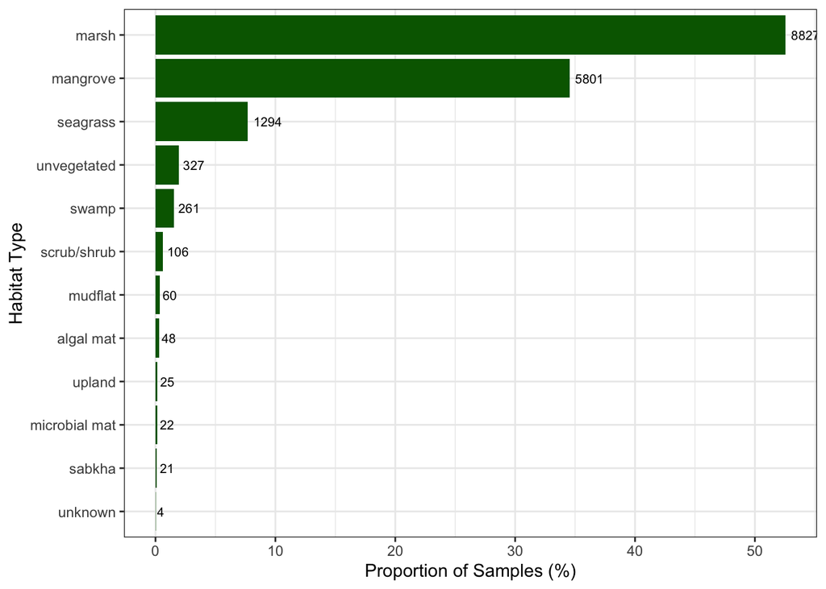

The following table shows which cores are currently not assigned any habitat:

| study_id | site_id | core_id | year | month | day | core_notes | latitude | longitude | elevation | elevation_datum | country | admin_division | stocks_qual_code | max_depth |
| --- | --- | --- | --- | --- | --- | --- | --- | --- | --- | --- | --- | --- | --- | --- |
| Osland_et_al_2016 | Ten_Thousand_Islands | ten_thousand_islands_25 | 2014 | 12 | 3 | 15 cm | 25.86072123 | -81.54516968999998 | 0.5496 | NAVD88 | United States | Florida | C2 | 15 |
| Osland_et_al_2016 | Tampa_Bay | tampa_bay_34 | 2014 | 12 | 7 | water/oyster - 2nd dom | 27.5339929 | -82.64462674 | -0.4691 | NAVD88 | United States | Florida | C2 | 15 |
| Osland_et_al_2016 | Tampa_Bay | tampa_bay_35 | 2014 | 12 | 7 | oyster/mangroves - 1st dom | 27.533984 | -82.64461649 | -0.3124 | NAVD88 | United States | Florida | C2 | 15 |
| Osland_et_al_2016 | Tampa_Bay | tampa_bay_45 | 2014 | 12 | 7 | 15 cm | 27.53388605 | -82.64450365 | 0.9799000000000002 | NAVD88 | United States | Florida | C2 | 15 |

### Geography

The following table shows which cores are currently not assigned any country. This may be because the latitude and longitude are undefined.

| study_id | site_id | core_id | latitude | longitude |
| --- | --- | --- | --- | --- |
| Thom_1992 |  | SB1 | unknown | unknown |
| Thom_1992 | South_Slough | SS1 | unknown | unknown |
| Drexler_et_al_2013 | Coastal_EDU_Field | Coastal_EDU_Field_2 | unknown | unknown |

### Depthseries

**Depth Interval Checks**

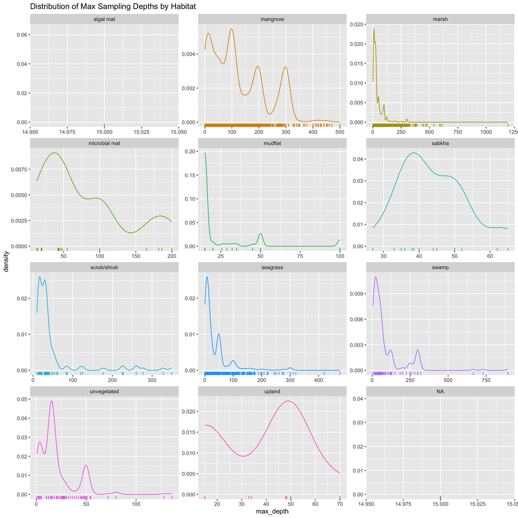

**The following studies have cores with a max depth of NA or 0: Nahlik_and_Fennessy_2016, Mbense_et_al_2016, Langston_et_al_2022, Agawin_et_al_1996, De_Iongh_et_al_1995, Holmer_et_al_2007, Townsend_and_Fonseca_1998, Van_Engeland_2010**

Instances of multiple observations for the same interval within a unique core (and unique method ID) were found in the following 47 studies:

Boyd_et_al_2017, Brown_et_al_2026, Buffington_et_al_2020, Callaway_et_al_2019, Cifuentes_et_al_2024_ElSalvador, CRMS_Database, Drexler_et_al_2009, Drexler_et_al_2013, Everhart_et_al_2020, Fourqurean_and_Kendrick_unpublished, Geldenhyus_et_al_2016, Gerlach_et_al_2017, Gonneea_et_al_2004, Howard_and_Fourqurean_2020, Human_et_al_2022, Johnson_et_al_2020, Johnson_et_al_2024_eelgrass, Kemp_et_al_2020, Kemp_et_al_2023, Kemp_et_al_2024, Kumar_et_al_2020, Langston_et_al_2022, MacKenzie_et_al_2021, Marot_et_al_2020, Mbense_et_al_2016, Messerschmidt_and_Kirwan_2020, Nahlik_and_Fennessy_2016, NCSS, Oakes_and_Connolly_2004, Orson_1990, Paula_et_al_2001, Peer_et_al_2018, Quafisi_et_al_2024, Rajkaran_and_Adams_2011, Rigollet_et_al_2004, Romero_et_al_2025, Schieder_and_Kirwan_2019, Smeaton_et_al_2022b, Smeaton_et_al_2023, Stahl_et_al_2024, StLaurent_et_al_2020, Strand_et_al_2024, Trettin_et_al_2017, Tully_et_al_2024, Van_de_Broek_et_al_2018, Wang_et_al_2023, Watson_and_Byrne_2013

There are 4666 single-interval surface samples (max depth < 20cm) and 189 single-interval subsurface samples. There are also 689 large single-interval samples (ex. one representative (?) sample for 0-100cm depth).

The following 3 studies had at least one depth interval where the depth max was less than the depth min: Bezuidenhout_et_al_2011, DelVecchia_et_al_2014, Thom_1992

**Numeric Data Distributions**

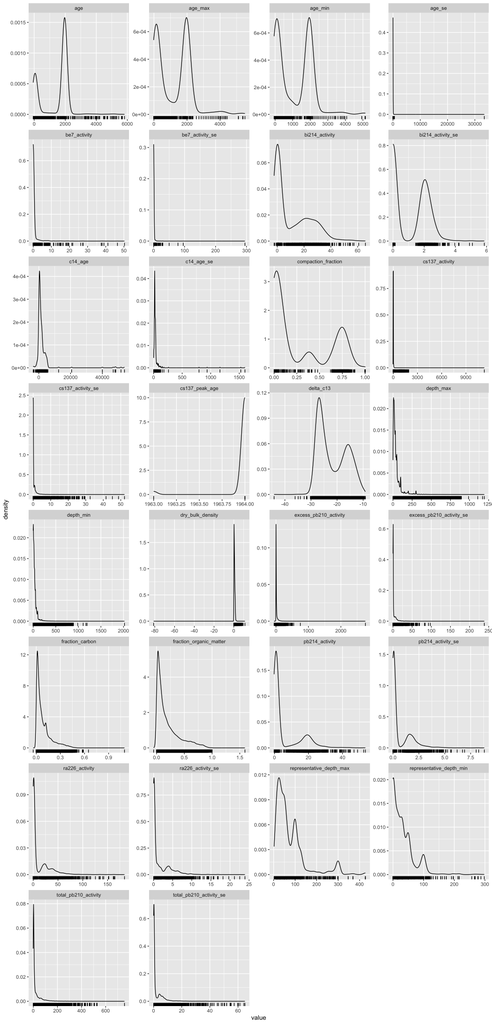

**Relationship between organic matter (LOI) and carbon content**

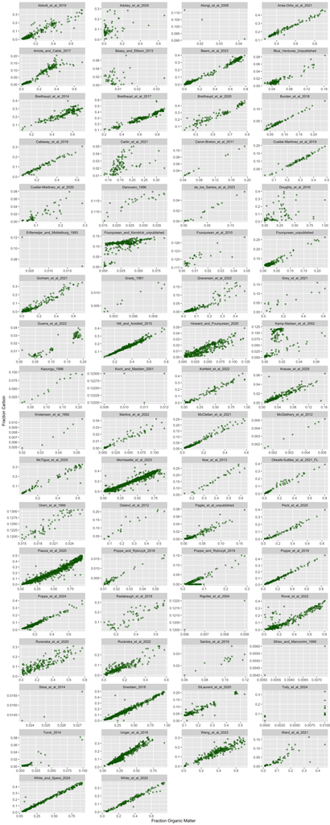

## Change Log

There are 82 new cores in this synthesis compared to the previous version. These come from 2 studies, 1 habitats, and 1 countries.

### Habitats with New Data

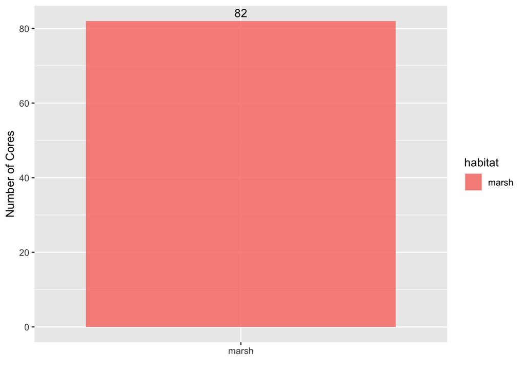

New species: Frankenia grandifolia

**Distribution of max sampling depths in the new data:**

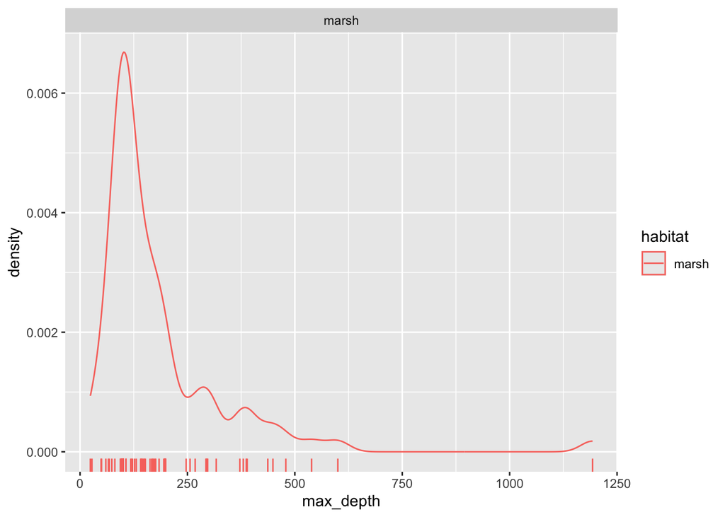

### Countries with New Data

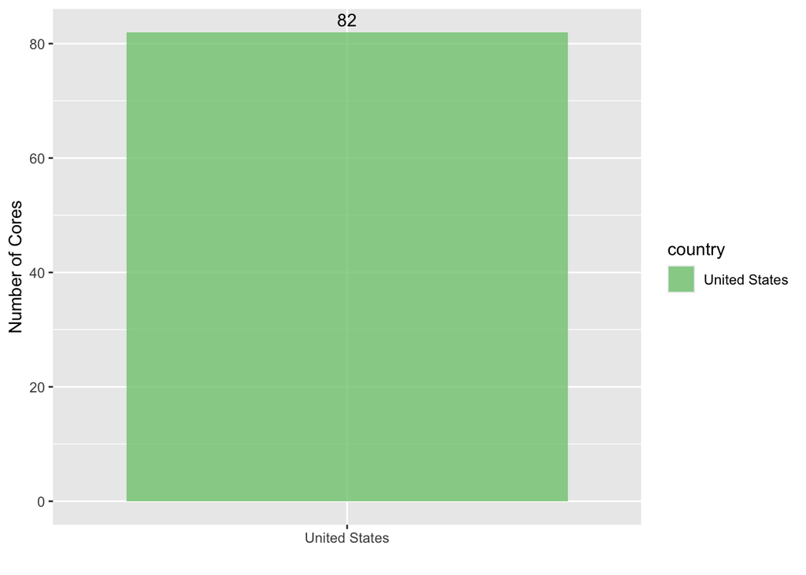

### Table of New Cores

|  | change_flag | study_id | site_id | core_id | habitat | country | max_depth |
| --- | --- | --- | --- | --- | --- | --- | --- |
| 1 | new core from new study | Brown_et_al_2026 | Bodega Bay | BOD13-02 | marsh | United States | 152 |
| 2 | new core from new study | Brown_et_al_2026 | Bolinas Lagoon | BOL13-01 | marsh | United States | 141 |
| 3 | new core from new study | Brown_et_al_2026 | Bolinas Lagoon | BOL13-02 | marsh | United States | 176 |
| 4 | new core from new study | Brown_et_al_2026 | Bolinas Lagoon | BOL13-03 | marsh | United States | 97 |
| 5 | new core from new study | Brown_et_al_2026 | Bolinas Lagoon | BOL13-04 | marsh | United States | 100 |
| 6 | new core from new study | Brown_et_al_2026 | Eureka | ERK13-01 | marsh | United States | 389 |
| 7 | new core from new study | Brown_et_al_2026 | Hookton Slough | HKS16-01 | marsh | United States | 100 |
| 8 | new core from new study | Brown_et_al_2026 | Hookton Slough | HKS16-02 | marsh | United States | 100 |
| 9 | new core from new study | Brown_et_al_2026 | Hookton Slough | HKS17-03 | marsh | United States | 372 |
| 10 | new core from new study | Brown_et_al_2026 | Jacoby | JCB13-01 | marsh | United States | 380 |

[output cut: 72 more lines]

## Miscellaneous

The following files were found in the derivative folders. They either do not match the approved filename structure for csvs or are another filetype

#### Unknown CSVs

```
##  [1] "data/primary_studies/Adotey_et_al_2024/derivative/Adotey_et_al_2024_allometric_eq.csv"
##  [2] "data/primary_studies/Adotey_et_al_2024/derivative/Adotey_et_al_2024_plant.csv"
##  [3] "data/primary_studies/Adotey_et_al_2024/derivative/Adotey_et_al_2024_plot_summary.csv"
##  [4] "data/primary_studies/CIFOR/derivative_ALT/cifor_alt_allometric_eq.csv"
##  [5] "data/primary_studies/CIFOR/derivative_ALT/cifor_alt_plant_plot_summary.csv"
##  [6] "data/primary_studies/CIFOR/derivative_SWAMP/cifor_swamp_allometric_eq.csv"
##  [7] "data/primary_studies/Craft_2024/derivative/Craft_2024_associated_publication.csv"
##  [8] "data/primary_studies/Dontis_et_al_2020/derivative/Dontis_et_al_2020_allometric_eq.csv"
##  [9] "data/primary_studies/Dontis_et_al_2020/derivative/Dontis_et_al_2020_plant.csv"
## [10] "data/primary_studies/Dontis_et_al_2020/derivative/Dontis_et_al_2020_plot_summary.csv"
## [11] "data/primary_studies/Fourqurean_2012/derivative/Fourqurean_2012_biomass.csv"
## [12] "data/primary_studies/Gillen_et_al_2018/derivative/Gillen_et_al_2018_plant_plot_detail.csv"
## [13] "data/primary_studies/Gillen_et_al_2018/derivative/Gillen_et_al_2018_plot_summary.csv"
## [14] "data/primary_studies/Johnson_et_al_2024_seagrass/derivative/Johnson_et_al_2024_eelgrass.csv"
## [15] "data/primary_studies/Morgan_et_al_2024/derivative/morgan_et_al_2024_plot_summary.csv"
## [16] "data/primary_studies/Radabaugh_et_al_2017/derivative/radabaugh_et_al_2017_allometric_eq.csv"
## [17] "data/primary_studies/Radabaugh_et_al_2017/derivative/radabaugh_et_al_2017_plant_plot_detail.csv"
## [18] "data/primary_studies/Radabaugh_et_al_2017/derivative/radabaugh_et_al_2017_plant.csv"
## [19] "data/primary_studies/Radabaugh_et_al_2017/derivative/radabaugh_et_al_2017_plot_summary.csv"
## [20] "data/primary_studies/Radabaugh_et_al_2018/derivative/radabaugh_et_al_2018_plot_summary.csv"
## [21] "data/primary_studies/Radabaugh_et_al_2023/derivative/radabaugh_et_al_2023_allometric_eq.csv"
## [22] "data/primary_studies/Radabaugh_et_al_2023/derivative/radabaugh_et_al_2023_plant.csv"
## [23] "data/primary_studies/Radabaugh_et_al_2023/derivative/radabaugh_et_al_2023_plot_summary.csv"
## [24] "data/primary_studies/Simard_et_al_2019/derivative/Simard_et_al_2019_plant_plot_detail.csv"
## [25] "data/primary_studies/Trettin_et_al_2020/derivative/trettin_et_al_2020_study_citation.csv"
```

#### Non .csv or .bib filetypes

```
##  [1] "data/primary_studies/Brown_et_al_2024/derivative/_readMe.txt"
##  [2] "data/primary_studies/Darienzo_and_Peterson_1990/derivative/_readMe.rtf"
##  [3] "data/primary_studies/Dontis_et_al_2020/derivative/_readMe.txt"
##  [4] "data/primary_studies/Everhart_et_al_2020/derivative/_readMe.txt"
##  [5] "data/primary_studies/Gillen_et_al_2018/derivative/_readMe.txt"
##  [6] "data/primary_studies/Langston_et_al_2022/derivative/_readMe.txt"
##  [7] "data/primary_studies/Messerschmidt_et_al_2020/derivative/_readMe.txt"
##  [8] "data/primary_studies/Morgan_et_al_2024/derivative/_readMe.rtf"
##  [9] "data/primary_studies/Radabaugh_et_al_2017/derivative/_readMe.txt"
## [10] "data/primary_studies/Radabaugh_et_al_2018/derivative/_readMe.txt"
## [11] "data/primary_studies/Radabaugh_et_al_2021/derivative/_readMe.txt"
## [12] "data/primary_studies/Radabaugh_et_al_2023/derivative/_readMe.txt"
## [13] "data/primary_studies/Simard_et_al_2019/derivative/_readMe.rtf"
## [14] "data/primary_studies/Smith_and_Kirwan_2021/derivative/_readMe.txt"
## [15] "data/primary_studies/Stevens_et_al_2024/derivative/_readMe.txt"
## [16] "data/primary_studies/Vinent_and_Kirwan_2017/derivative/_readMe.txt"
```

#### Warnings Encountered

```
## 1 identical warnings:
## There were 2 warnings in `mutate()`.
## The first warning was:
## ℹ In argument: `across(everything(), as.numeric)`.
## Caused by warning:
## ! NAs introduced by coercion
## ℹ Run dplyr::last_dplyr_warnings() to see the 1 remaining warning.
```